# Fibonacci Sequence: Non Recursive Formula

Plots and comparison to Exponential and notes on Power equations

Feb 8, 2023 • Deebul Nair • 2 min read

fun loss

- Fibonacci Sequence: Non Recursive Formula
  - Generalizing the Fibonacci equation
    - Comparing with the exponential equation
    - Comparing with the exponential equation (region [0 - 1])
- Random Ideas
  - Observations
  - Converting the power equation to loss function

# Fibonacci Sequence: Non Recursive Formula

> Plots and comparison to Exponential

In a series of [Twitter posts](https://twitter.com/TivadarDanka/status/1622922634907488256) by Matematician [Tivadar Danka](https://www.tivadardanka.com/) demonstrated the non recursive formula for the Fibonacci sequence.

[figure not shown]

I wanted to plot this equation and compare it with the exponential equation.

In the process I did some updates to the equation.

1. Took the absolute of the conjugate golden ratio. This helped in removing the imaginary part( (-0.6)** 1.5 = has an imaginary element)
2. I tried to generalize the equation and find the other forms and a equation near to exponential

```python
golden_ratio = (1 + 5**0.5 )/2
conjugate_golden_ratio = (1 - 5**0.5 )/2

print ("Golden Ratio :", golden_ratio)
print ("Conjugate Golden Ratio :", conjugate_golden_ratio)
```

```
Golden Ratio : 1.618033988749895
Conjugate Golden Ratio : -0.6180339887498949
```

```python
n = sym.symbols('n')
fibonacci = (sym.Pow(golden_ratio, n)  - sym.Pow(abs(conjugate_golden_ratio),n)) / (golden_ratio - conjugate_golden_ratio)
fibonacci
```

$\displaystyle - 0.447213595499958 \cdot 0.618033988749895^{n} + 0.447213595499958 \cdot 1.61803398874989^{n}$

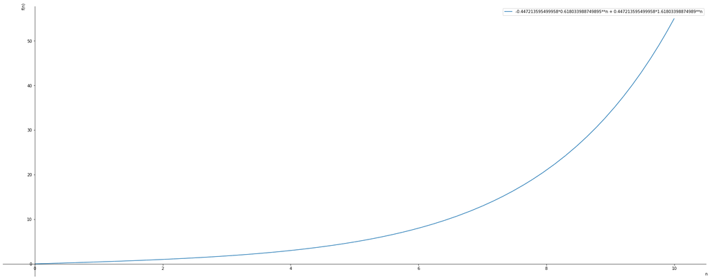

```
<sympy.plotting.plot.Plot at 0x7f8fa843c4f0>
```

```python
symplot.plot(fibonacci, (n,0,10), show=True, legend=True)
```

## Generalizing the Fibonacci equation

We generalize the Fibonnacci equation, by parametrizing the golden ratio and the conjugate of the golden ratio.

```python
# Generalized Fibonacci Equation

g, n = sym.symbols('g, n')

golden_ratio = (1 + g**0.5 )/2
conjugate_golden_ratio = (1 - g**0.5 )/2
fibonacci = (sym.Pow(golden_ratio, n)  - sym.Pow(abs(conjugate_golden_ratio),n)) / (golden_ratio - conjugate_golden_ratio)
fibonacci
```

$\displaystyle \frac{\left(\frac{g^{0.5}}{2} + \frac{1}{2}\right)^{n} - \left|{\frac{g^{0.5}}{2} - \frac{1}{2}}\right|^{n}}{g^{0.5}}$

### Comparing with the exponential equation

Based on the generalized fibonacci equation, we would like to find if we can can get an approximate of the exponential equation

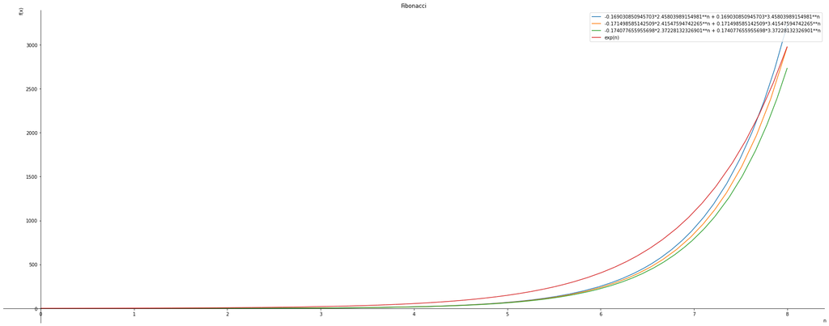

```python
#symplot.plot(fibonacci.subs(g, 4), (n,0,10), show=True, line_color='darkgreen')


graphs= sym.plotting.plot(fibonacci.subs(g, 35), fibonacci.subs(g, 34),fibonacci.subs(g, 33), sym.exp(n),  (n,0,8), title="Fibonacci", legend= True, xlabel='n', ylabel='f(x)', show=False)


for i, graph in enumerate(graphs):
 graph.line_color=color[i%len(color)]

graphs.show()
```

### Comparing with the exponential equation (region [0 - 1])

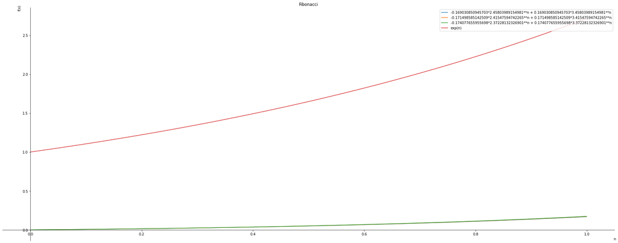

```python
#symplot.plot(fibonacci.subs(g, 4), (n,0,10), show=True, line_color='darkgreen')


graphs= sym.plotting.plot(fibonacci.subs(g, 35), fibonacci.subs(g, 34),fibonacci.subs(g, 33), sym.exp(n),  (n,0,1), title="Fibonacci", legend= True, xlabel='n', ylabel='f(x)', show=False)


for i, graph in enumerate(graphs):
 graph.line_color=color[i%len(color)]

graphs.show()
```

# Random Ideas

Comparison with the Power equations.

$$ f(n) = constant^{n} $$

## Observations

1. The constant if less than 1 then it inverts
2. If constant is 1 then the equation is flat
3. Higher the constant higher the slope

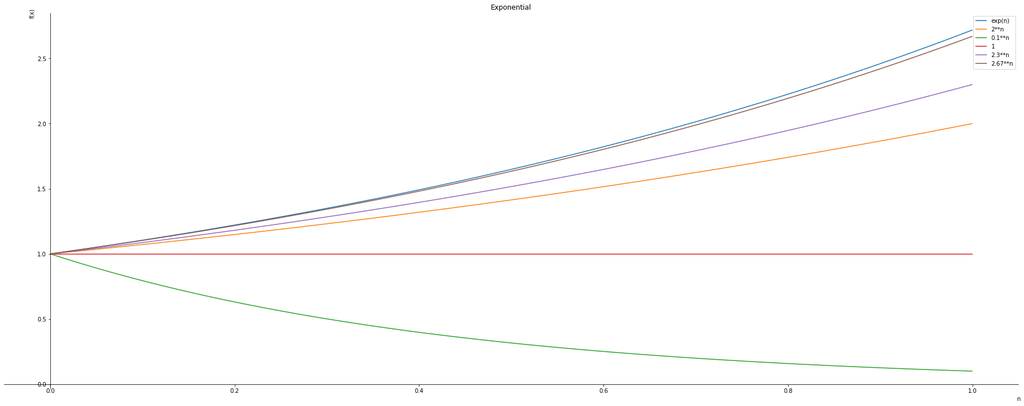

```python
graphs= sym.plotting.plot(sym.exp(n), 2**n, 0.1**n,1**n,2.3**n,2.67**n,(n,0.0,1), title="Exponential", legend= True, xlabel='n', ylabel='f(x)', show=False)


for i, graph in enumerate(graphs):
 graph.line_color=color[i%len(color)]

graphs.show()
```

## Converting the power equation to loss function

- Inoder to the make the loss function, for higher slope lines the loss at zero should be lesser
- so the highest slope equation should have lowest loss
- This is achieved by adding the inverse of the constant to the loss

$$ f(n) = constant^{n} + \frac{1}{constant} $$

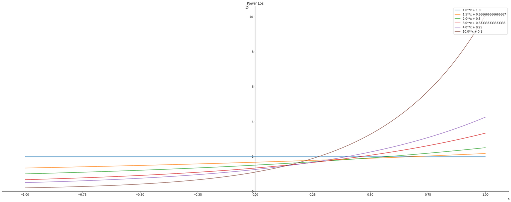

```python
n, x = sym.symbols('n, x')
loss = n**x + 1/n

#n hasto be grater than 1

graphs = sym.plotting.plot(loss.subs(n,1.),
                          loss.subs(n,1.5),
                          loss.subs(n,2.),
                          loss.subs(n,3.),
                          loss.subs(n,4.),
                          loss.subs(n,10.),
                          (x,-1,1), title="Power Los", legend= True, xlabel='x', ylabel='f(x)', show=False)

for i, graph in enumerate(graphs):
 graph.line_color=color[i%len(color)]

graphs.show()
```